# P-Set 2

E 310 Intro to Digital Studies, Hinrichs

Madison Liao

10-11-2020

## Setup

The first code chunk loads our two standard packages. Make sure not to delete this chunk.

```r
# This chunk is part of the quiz prompt.
if(!require(pacman)){install.packages("pacman")}
p_load(rio, tidyverse)
```

## Dataset 1: Austin Code Complaints

The first dataset for this project [download here](https://drive.google.com/file/d/1iUhJn_MHhBcRTrGHi9GanRhuxySPuQNx/view?usp=sharing) is a record of more than 100,000 code compliance complaints received by the City of Austin. It’s pretty current: the most recent entries are from this month.

Here is the proper citation:

> Austin Code Department. 2020. Austin Code Complaint Cases. opendataatx. https://doi.org/10.26000/011.000001.

## Questions

The number of points possible for each question is shown after the question label.

#### Q1 (2)

Load the data file `Austin_Code_Complaint_Cases.csv` into R by using the `import()` function (which is included in the `rio` package, loaded in the `setup` chunk above).[^2]

```r
df <- import("Austin_Code_Complaint_Cases.csv")
```

In its current version, the dataset has column names that are all upper case, which is cumbersome to work with.

```r
# This chunk is part of the quiz prompt.
df %>% colnames()
```

```
 [1] "CASE_ID"      "PRIORITY"     "STATUS"       "ADDRESS_LONG" "HOUSE_NUMBER" "STREET_NAME"  "CITY"
 [8] "STATE"        "ZIP_CODE"     "OPENED_DATE"  "CLOSED_DATE"  "DEPARTMENT"   "CASE_TYPE"    "DESCRIPTION"
[15] "CASE_CONTACT" "CASE_MANAGER" "DATE_UPDATED" "LAST_UPDATE"  "LATITUDE"     "LONGITUDE"    "Location"
```

In the next chunk, which I am providing and you just need to execute,[^3] we apply the function `clean_names()` from the `janitor` package. It puts the column names into a nicer format than how they come.

```r
# This chunk is part of the quiz prompt.
p_load(janitor)
df <- df %>%
  clean_names()
df %>% colnames()
```

```
 [1] "case_id"      "priority"     "status"       "address_long" "house_number" "street_name"  "city"
 [8] "state"        "zip_code"     "opened_date"  "closed_date"  "department"   "case_type"    "description"
[15] "case_contact" "case_manager" "date_updated" "last_update"  "latitude"     "longitude"    "location"
```

That looks much better. Now let’s continue looking at the dataset.

#### Q2 (2)

Write some code that produces output showing how many rows and columns are in the data.[^4]

```r
df %>%
  dim()
```

```
[1] 107493     21
```

#### Q3 (2)

In order to see the names and data types of all columns, pipe the dataset into the `glimpse()` function.

```r
df %>% glimpse()
```

```
Rows: 107,493
Columns: 21
$ case_id      <chr> "2020-125370 CC", "2020-126602 CC", "2020-043887 CC", "2020-107748 CC", "2020-127753 CC", "20…
$ priority     <int> 5, 2, 5, 2, 5, 5, 5, 5, 2, 5, 2, 2, 5, 5, 5, 5, 2, 2, 2, 2, 5, 2, 3, 5, 4, 5, 5, 5, 2, 5, 2, …
$ status       <chr> "Closed", "Closed", "Closed", "Closed", "Active", "Closed", "Active", "Closed", "Closed", "Cl…
$ address_long <chr> "6100 BLK  WEST GATE BLVD", "9219 ANDERSON MILL RD Building 1", "1901  WILLOW CREEK DR  Bldg …
$ house_number <chr> "", "9219", "1901", "3004", "3105", "701", "5935", "", "9219", "3504", "11410", "605", "7601"…
$ street_name  <chr> "", "ANDERSON MILL RD", "WILLOW CREEK DR", "COLLINS CREEK DR", "FRITZ HUGHES PARK RD", "TRINI…
$ city         <chr> "", "AUSTIN", "AUSTIN", "AUSTIN", "AUSTIN", "AUSTIN", "AUSTIN", "", "AUSTIN", "AUSTIN", "AUST…
$ state        <chr> "", "TX", "TX", "TX", "TX", "TX", "TX", "", "TX", "TX", "TX", "TX", "TX", "", "TX", "TX", "TX…
$ zip_code     <int> NA, 78729, 78741, 78741, 78732, 78701, 78745, NA, 78729, 78704, 78758, 78703, 78744, NA, 7874…
$ opened_date  <chr> "8/22/20", "8/25/20", "3/16/20", "7/20/20", "8/26/20", "7/1/20", "1/28/18", "8/7/20", "8/25/2…
$ closed_date  <chr> "9/28/20", "8/26/20", "8/28/20", "8/28/20", "", "8/28/20", "", "8/27/20", "8/28/20", "8/25/20…
$ department   <chr> "Code Enforcement", "Code Enforcement", "Code Enforcement", "Code Enforcement", "Code Enforce…
$ case_type    <chr> "Complaints", "Complaints", "Complaints", "Complaints", "Complaints", "Complaints", "Complain…
$ description  <chr> "Property Abatement", "Structure Condition Violation(s)", "Structure Condition Violation(s)",…
$ case_contact <chr> "", "9219 ANDERSON LLC % GOLD STANDARD ASSET MANAGEMENT", "1911 WILLOW CREEK LLC", "SHFC OAK …
$ case_manager <chr> "Jeffrey Moody|512-974-9723", "Reynaldo Cruz|(512)974-3615", "Jason Ortiz|(512) 974-2385", "L…
$ date_updated <chr> "9/28/20 0:00", "8/26/20 0:00", "8/28/20 0:00", "8/28/20 0:00", "8/28/20 0:00", "8/28/20 0:00…
$ last_update  <chr> "Closed due to Voluntary Compliance", "Follow-up Inspection", "Closed due to Voluntary Compli…
$ latitude     <dbl> 30.51082, 30.45093, 30.23394, 30.22303, 30.38118, 30.26822, 30.20712, 30.51082, 30.45093, 30.…
$ longitude    <dbl> -97.74701, -97.78260, -97.72788, -97.73207, -97.91325, -97.73869, -97.78899, -97.74701, -97.7…
$ location     <chr> "(30.51081514, -97.74700986)", "(30.45092881, -97.78260329)", "(30.23394374, -97.72787696)", …
```

#### Q4 (3)

In order to get a sense of what’s in some of the columns, use `count()` to see the values (and their frequencies) for the columns `case_type`, `zip_code` and `description`.[^5]

```r
df %>%
  count(case_type)
```

| case_type | n |
| --- | --- |
| Complaints | 107493 |

```r
df %>%
  count(zip_code)
```

| zip_code | n |
| --- | --- |
| 78613 | 99 |
| 78617 | 1114 |
| 78620 | 1 |
| 78641 | 3 |
| 78652 | 31 |
| 78653 | 60 |
| 78660 | 121 |
| 78664 | 1 |
| 78681 | 5 |
| 78701 | 4072 |

[output cut: 47 more lines]

```r
NA
```

```r
df %>%
  count(description)
```

| description | n |
| --- | --- |
|  | 489 |
| Land Use Violation(s) | 33781 |
| Property Abatement | 40283 |
| Structure Condition Violation(s) | 30003 |
| Structure Condition Violations | 2 |
| SWS Chp 15 Violation(s) | 168 |
| Unknown | 1 |
| Work Without Permit | 2766 |

#### Q5 (2)

Write code that answers the question: which zip codes produce the most code complaints? The output should be a table, not a plot.

```r
df %>%
count(zip_code) %>%
  arrange(desc(n)) %>%
group_by(zip_code)
```

| zip_code | n |
| --- | --- |
| NA | 13934 |
| 78704 | 7254 |
| 78753 | 6588 |
| 78745 | 6530 |
| 78702 | 6240 |
| 78758 | 5907 |
| 78741 | 5806 |
| 78723 | 5383 |
| 78744 | 5035 |
| 78705 | 4468 |

[output cut: 47 more lines]

```r
NA
```

#### Q6 (3)

Write code that will produce a barchart using `ggplot()` in which the height of each bar corresponds to the frequency of one of the levels in the `priority` column.[^6]

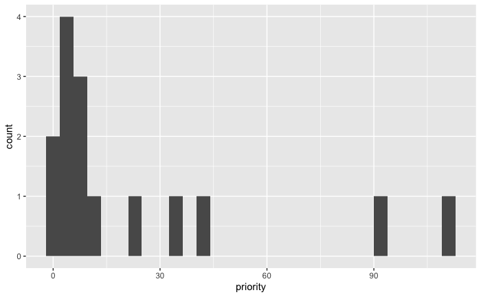

```r
df  %>%
 count(priority) %>%

ggplot(aes(x = priority)) +
geom_histogram()
```

## Dataset 2: Cities over 300,000

In order to practice making histograms, I searched for data with a continuous variable at the center of it, such as population sizes. So I got this one.

> Greater London Authority. Global City Population Estimates. 2018. https://data.gov.uk/dataset/128a0e7c-e51e-4fba-b743-289e2a8debdf/global-city-population-estimates.

#### Q7 (2)

Load the dataset “global-city-population-estimates.xls” as `df2` and apply the `clean_names()` as above, in the same pipeline that contains the `import()` function.[^7]

```r
df2 <- import("global-city-population-estimates.csv") %>%
  clean_names()
df2 %>% colnames()
```

```
 [1] "country_code"        "country_or_area"     "city_code"           "urban_agglomeration" "note"
 [6] "latitude"            "longitude"           "x1950"               "x1955"               "x1960"
[11] "x1965"               "x1970"               "x1975"               "x1980"               "x1985"
[16] "x1990"               "x1995"               "x2000"               "x2005"               "x2010"
[21] "x2015"               "x2020"               "x2025"               "x2030"               "v25"
[26] "v26"                 "v27"
```

#### Q8 (4)

Create a simple histogram with `ggplot()` of all population sizes in `df2.` Visualize only the year 2015. Make sure to adjust the bin size in a way that makes sense for this data. Underneath the code chunk, you can include a short statement justifying your choice of bin size.

```
Problem with `mutate()` input `x2015`.
ℹ NAs introduced by coercion
ℹ Input `x2015` is `as.numeric(x2015)`.NAs introduced by coercion
```

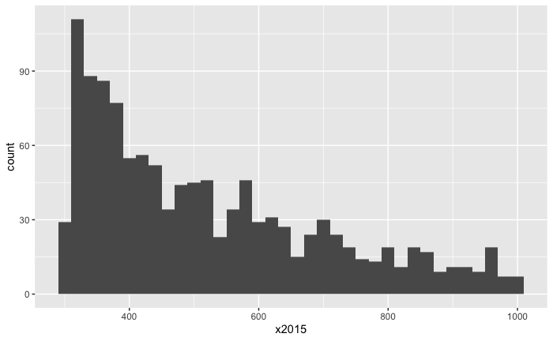

```r
  df2 %>%
  mutate(x2015 = as.numeric(x2015)) %>%
  ggplot(aes(x = x2015)) +
  geom_histogram(binwidth = 20)
```

```r
  df3 <- filter(df2, country_or_area %in% c("India","Pakistan","Bangladesh","United States of America")) %>%
select(1, 2, 21) %>%
tibble()
df3
```

| country_code | country_or_area | x2015 |
| --- | --- | --- |
| 356 | India | 25,703 |
| 356 | India | 21,043 |
| 840 | United States of America | 18,593 |
| 50 | Bangladesh | 17,598 |
| 586 | Pakistan | 16,618 |
| 356 | India | 14,865 |
| 840 | United States of America | 12,310 |
| 356 | India | 10,087 |
| 356 | India | 9,890 |
| 356 | India | 8,944 |

[output cut: 326 more lines]

```r
NA
```

#### Q10 (4)

Create a complex histograms of the population sizes in `df3` that shows one panel per country (i.e. it should show 4 panels). This panel should use the `facet_grid()` function as one of the layers of the `ggplot()` specification. See [this reading](https://e310d.netlify.app/posts/2020-09-25-plotsaggregationfunctions/).

```
Problem with `mutate()` input `x2015`.
ℹ NAs introduced by coercion
ℹ Input `x2015` is `as.numeric(x2015)`.NAs introduced by coercion
```

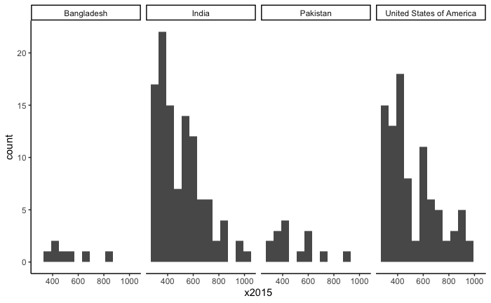

```r
df3 %>%
  mutate(x2015 = as.numeric(x2015)) %>%
  ggplot(aes(x = x2015)) +
  geom_histogram(binwidth = 60) +
  facet_grid(~country_or_area) +
  theme_classic()
```

#### Extra credit 1 (2)

Show the code that changes the format of `df2` from wide to long. Again, see [this reading](https://e310d.netlify.app/posts/2020-09-25-plotsaggregationfunctions/). In order to make this change, ask yourself this question: in what way is the data untidy, i.e. what information is included in each row that should really be broken up into separate rows?

Don’t create a new data object; instead, overwrite `df2`.

```r
df2<- df2 %>%
  pivot_longer(
    cols = 8:27,
    names_to = "variable",
    values_to = "value"
  )
df2 %>%
  head(27) %>%
  tibble()
```

| country_code | country_or_area | city_code | urban_agglomeration | note | latitude | longitude | variable | value |
| --- | --- | --- | --- | --- | --- | --- | --- | --- |
| 392 | Japan | 21671 | Tokyo | 325 | 35.68950 | 139.69171 | x1950 | 11,275 |
| 392 | Japan | 21671 | Tokyo | 325 | 35.68950 | 139.69171 | x1955 | 13,713 |
| 392 | Japan | 21671 | Tokyo | 325 | 35.68950 | 139.69171 | x1960 | 16,679 |
| 392 | Japan | 21671 | Tokyo | 325 | 35.68950 | 139.69171 | x1965 | 20,284 |
| 392 | Japan | 21671 | Tokyo | 325 | 35.68950 | 139.69171 | x1970 | 23,298 |
| 392 | Japan | 21671 | Tokyo | 325 | 35.68950 | 139.69171 | x1975 | 26,615 |
| 392 | Japan | 21671 | Tokyo | 325 | 35.68950 | 139.69171 | x1980 | 28,549 |
| 392 | Japan | 21671 | Tokyo | 325 | 35.68950 | 139.69171 | x1985 | 30,304 |
| 392 | Japan | 21671 | Tokyo | 325 | 35.68950 | 139.69171 | x1990 | 32,530 |
| 392 | Japan | 21671 | Tokyo | 325 | 35.68950 | 139.69171 | x1995 | 33,587 |

[output cut: 17 more lines]

```r
NA
```

#### Extra credit 2 (2)

Having pivoted the format of `df2` from wide to long, produce a plot now that visualizes population sizes over time. Assign the year to the `x`-axis. It’s up to you what specifically you want to put on the `y`-axis; there’s a number of things you could do with `df2`. If you manage to produce a meaningful plot in response to this question, you’ll all possible extra credit points.

```r
df2%>%
plot(variable, value ,panel.first = grid)
```

```
Error in match.fun(panel) : object 'value' not found
```

[^1]: In the Rmd version of the file, this link is long and ugly. Notice how when you click Preview, it turns into a pretty hyperlink.
[^2]: Unlike what we did in some of the exercises, the file is not in a separete “data” directory, so to specify its location, it will be enough to just pass its name in double quotes to the `import()` function.
[^3]: You can always manually execute a chunk by clicking on the Play button at the top right of the chunk. Alternatively, it will be executed any time you hit “Preview”.
[^4]: This question, as many of the ones in this quiz, has several possible correct answers.
[^5]: If you’d like to use separate code chunks for these statements, you can easily insert new ones by clicking on “Insert” above, next to the “Preview” button.
[^6]: Note: There is no need to sort the bars by their heights. Also, remember that there are two different `geom`s that produce bar charts in `ggplot()`: `geom_bar()` and `geom_col()`.
[^7]: Since `janitor` was loaded above, there is no need to load it again.